# Network Construction

```r
library(rmarkdown)
library(rmdformats)
library(ggplot2)
library(dplyr)
library(readr)
library(tibble)
library(magrittr)
library(WGCNA)
library(here)

placenta_data <- read_csv(here("data/placenta_data_wgcna.csv")) %>%
  column_to_rownames("sample_id")
```

# WGCNA Network Construction

**Prior to identifying which genes are correlated with each other, need to select a soft power threshold**

A **soft-power threshold** represents how stringently one can identify correlations between gene expression in two or more samples. Essentially the correlation value of each gene to each other gene will be raised to this number to reduce noise and identify biologically significant correlation.

Select a value that is sufficiently high to reduce biologically meaningless/spurious correlations but not too large to the point where correlations can’t be identified. Plot the scale independence and mean connectivity to visualise the effect of different soft power levels on the formation of the adjacency matrix (and hence the network).

Select based on where the plot plateau is, the r^2, and the mean connectivity being below 100

## Soft Power Estimates

```r
set.seed(1201)

powers <- 1:20

sftList <- pickSoftThreshold(placenta_data,
                             powerVector = powers,
                             verbose = 0,
                             networkType = "signed",
                             RsquaredCut = 0.87)
```

```
##    Power SFT.R.sq slope truncated.R.sq mean.k. median.k. max.k.
## 1      1   0.0236  8.43          0.948  4680.0   4690.00   4900
## 2      2   0.0300 -1.66          0.860  2620.0   2610.00   3030
## 3      3   0.2300 -1.90          0.790  1580.0   1540.00   2180
## 4      4   0.4410 -1.62          0.837  1020.0    959.00   1670
## 5      5   0.5860 -1.48          0.865   687.0    625.00   1340
## 6      6   0.6880 -1.43          0.893   483.0    420.00   1110
## 7      7   0.7520 -1.39          0.912   352.0    291.00    937
## 8      8   0.8000 -1.37          0.929   263.0    205.00    804
## 9      9   0.8300 -1.36          0.941   202.0    147.00    699
## 10    10   0.8480 -1.37          0.942   158.0    108.00    614
## 11    11   0.8630 -1.39          0.948   126.0     79.50    545
## 12    12   0.8740 -1.41          0.950   101.0     59.30    488
## 13    13   0.8680 -1.42          0.945    83.0     44.60    439
## 14    14   0.8670 -1.43          0.942    68.7     34.00    397
## 15    15   0.8690 -1.44          0.944    57.4     26.20    360
## 16    16   0.8620 -1.45          0.939    48.5     20.40    329
## 17    17   0.8780 -1.44          0.951    41.2     15.90    301
## 18    18   0.8830 -1.44          0.955    35.3     12.50    277
## 19    19   0.8910 -1.43          0.963    30.5      9.93    255
## 20    20   0.8940 -1.43          0.967    26.4      7.90    235
```

```r
sftList$fitIndices %>%
  mutate(across(where(is.numeric), ~ round(., 3)))
```

```
##    Power SFT.R.sq  slope truncated.R.sq  mean.k. median.k.   max.k.
## 1      1    0.024  8.426          0.948 4683.751  4685.079 4901.117
## 2      2    0.030 -1.657          0.860 2616.694  2605.009 3029.574
## 3      3    0.230 -1.902          0.790 1582.025  1538.709 2177.895
## 4      4    0.441 -1.617          0.837 1017.168   959.353 1673.704
## 5      5    0.586 -1.485          0.865  687.155   625.210 1342.600
## 6      6    0.688 -1.425          0.893  483.414   419.834 1109.389
## 7      7    0.752 -1.390          0.912  351.713   290.538  936.645
## 8      8    0.800 -1.373          0.929  263.204   204.807  803.776
## 9      9    0.830 -1.363          0.941  201.710   147.018  699.057
## 10    10    0.848 -1.375          0.942  157.745   107.675  614.497
## 11    11    0.863 -1.391          0.948  125.524    79.477  545.339
## 12    12    0.874 -1.409          0.950  101.394    59.281  487.553
## 13    13    0.868 -1.422          0.945   82.980    44.574  438.583
## 14    14    0.867 -1.428          0.942   68.692    34.023  396.634
## 15    15    0.869 -1.435          0.944   57.442    26.209  360.366
## 16    16    0.862 -1.450          0.939   48.467    20.369  328.758
## 17    17    0.878 -1.440          0.951   41.224    15.894  301.020
## 18    18    0.883 -1.437          0.955   35.318    12.506  276.528
## 19    19    0.891 -1.430          0.963   30.456     9.933  254.783
## 20    20    0.894 -1.428          0.967   26.419     7.898  235.383
```

### Soft Power

Plot Soft Power to view if the cut-off is sound

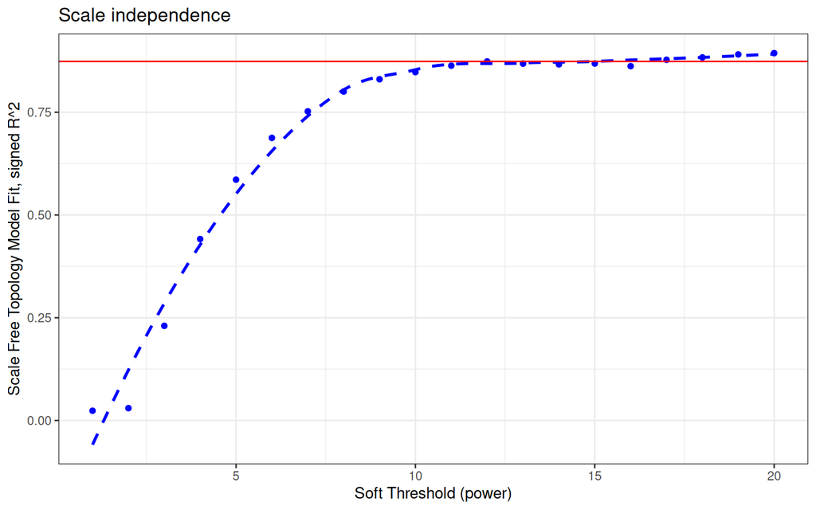

```r
ggplot(sftList$fitIndices,
       mapping = aes(x = Power,
                     y = SFT.R.sq,
                     color = "red")) +
  geom_point(colour = "blue") +
  geom_smooth(colour = "blue",
              se = FALSE,
              linetype = "dashed") +
  geom_hline(yintercept = 0.8736,
             colour = "red") +
  xlab("Soft Threshold (power)") +
  ylab("Scale Free Topology Model Fit, signed R^2") +
  ggtitle("Scale independence") +
  theme_bw() +
  guides(color = "none")
```

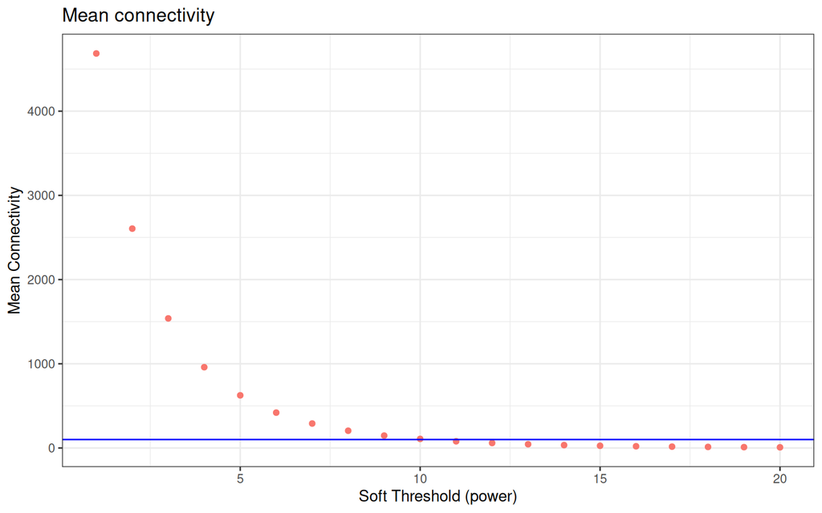

```r
ggplot(sftList$fitIndices,
       mapping = aes(x = Power,
                     y = median.k.,
                     color = "red")) +
  geom_point() +
  geom_hline(yintercept = 100,
             colour = "blue") +
  theme_bw() +
  guides(color = "none") +
  xlab("Soft Threshold (power)") +
  ylab("Mean Connectivity") +
  ggtitle("Mean connectivity")
```

The `pickSoftThreshold` function suggests the most appropriate soft-thresholding power to be used in network construction. 12 is the soft-threshold power suggested.

# Module Identification (groups of co-expressed genes)

**Next the adjacency matrix will be created for the formation of the gene co-expression network**

The **adjacency matrix** is a matrix that where the genes are both the columns and rows and the matrix is filled with the correlation value between each pair of genes.

In developing a network, the direction of the correlation of genes is important. The stringency applied when identifying biologically significant modules will increase by only identifying those genes which are positively correlated with one another.

## Topological overlap measurement

Once the network has been constructed, the detection of modules, or groups of co-expressed genes, is the next logical step. As such, modules are defined as clusters of densely interconnected genes, several measures of network interconnectedness exist the **topological overlap measure** (TOM) is used here.

The TOM can be used to cluster genes to form a “gene tree” where clusters of genes can be seen as leaves from the tree. The large matrix of distances between each gene and every other gene can be sorted into these clusters via TOM and hierarchical clustering.

When creating the modules, opt for larger modules for certainty that the genes are actually positively correlated, and so set `minModuleSize` to `40`. Then perform module identification using a hybrid adaptive tree cut

Finally convert numeric lables into colours for preparation of plotting the dendrograms of the clustered modules using `labels2colors`

```r
set.seed(1201)
soft_power <- sftList$powerEstimate

dissTOM <- (1 - (adjacency(placenta_data,
                           power = soft_power,
                           type = "signed") %>%
                   TOMsimilarity(TOMType = "signed")))
```

```
## ..connectivity..
## ..matrix multiplication (system BLAS)..
## ..normalization..
## ..done.
```

```r
geneTree <- dissTOM %>%
  as.dist() %>%
  hclust(method = "average")

minModuleSize <- 40

dynamicMods <- cutreeHybrid(dendro = geneTree,
                            distM = dissTOM,
                            minClusterSize = minModuleSize,
                            deepSplit = 1,
                            pamStage = FALSE,
                            verbose = 0)

dynamicColors <- labels2colors(dynamicMods$labels)

#rm(dissTOM)
```

Note each module is assigned a colour and **grey represents a module containing non-specific co-expressed genes**. Genes within this module are unlikely to have much relationship to each other therefore is ignored in many downstream analysis.

## Module Eigengenes

**In the following steps, module eigengenes and the distances between them are calculated and stored in the list object `MEeigen`. Module eigengenes are defines as:**

The first principle component of a certain module

**For each gene cluster, the first principle component (which is commonly referred to as a **module eigengene**), is calculated which permits summarisation of the expression pattern of the module of interest.**

The module eigengene can be used to correlate the expression of the module with phenotype or biological trait of interest.

```r
MEigen <- moduleEigengenes(placenta_data,
                           colors = dynamicColors)

MEDiss <- (1 - cor(MEigen$eigengenes))

METree <- MEDiss %>%
  as.dist() %>%
  hclust(method = "average")

MEDissThres = 0.20

sizeGrWindow(7, 6)
plot(METree,
     main = "Clustering of Placenta modules",
     xlab = "",
     sub = "")
abline(h = MEDissThres,
       col = "red")
```

[output not shown]

The distance threshold is the threshold in which closely related modules, that can subsequently be merged, are idententified. Merging closely related modules is essential as it allows the identification and definition of modules that are truly distinct, and also saves computation time and memory resources.

## Cluster Dendrogram

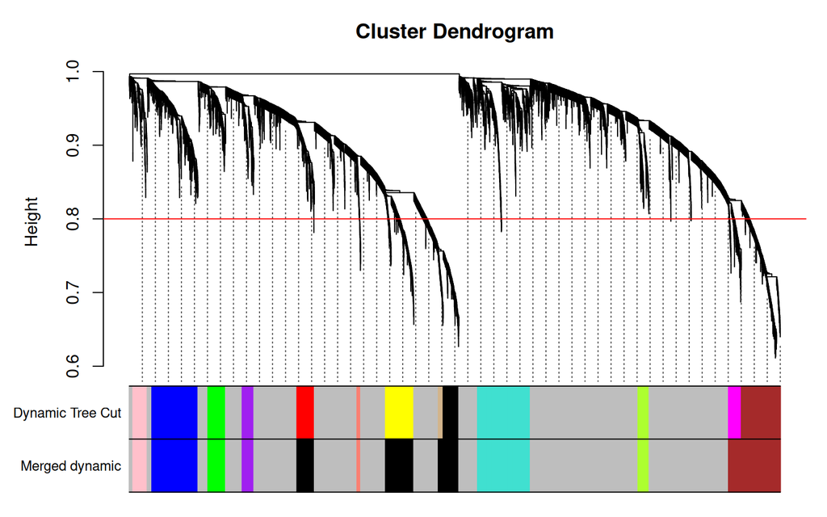

```r
merged_modules <- mergeCloseModules(placenta_data,
                                    dynamicColors,
                                    cutHeight = 0.20,
                                    verbose = 3)

merged_modules$newMEs %>%
  as.data.frame() %>%
  rownames_to_column(var = "ID") %>%
  as_tibble() %>%
  write_csv(here("data/module_eigengenes.csv"))

merged_modules$colors %>%
  write_rds(here("data/mergedColours.rds"))

merged_modules$colors

mergedColours <- merged_modules$colors

plotDendroAndColors(geneTree,
                    cbind(dynamicColors,
                          mergedColours),
                    c("Dynamic Tree Cut",
                      "Merged dynamic"),
                    dendroLabels = FALSE,
                    hang = 0.03,
                    addGuide = TRUE,
                    guideHang = 0.05,
                    abHeight = 0.8,
                    abCol = "red")
```